# Taller RLM 2

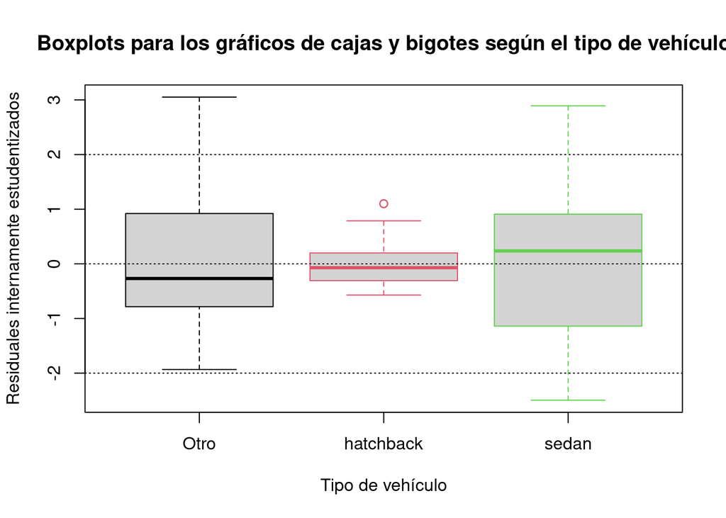

Gráficos de cajas y bigotes para los residuales estudentizados según el tipo de vehículo.

Luego, se debe verificar la normalidad de los residuales, ya que como se mencionó, se partió del supuesto de que los errores son normales, para lo cual vale la pena observar el siguiente QQ plot:

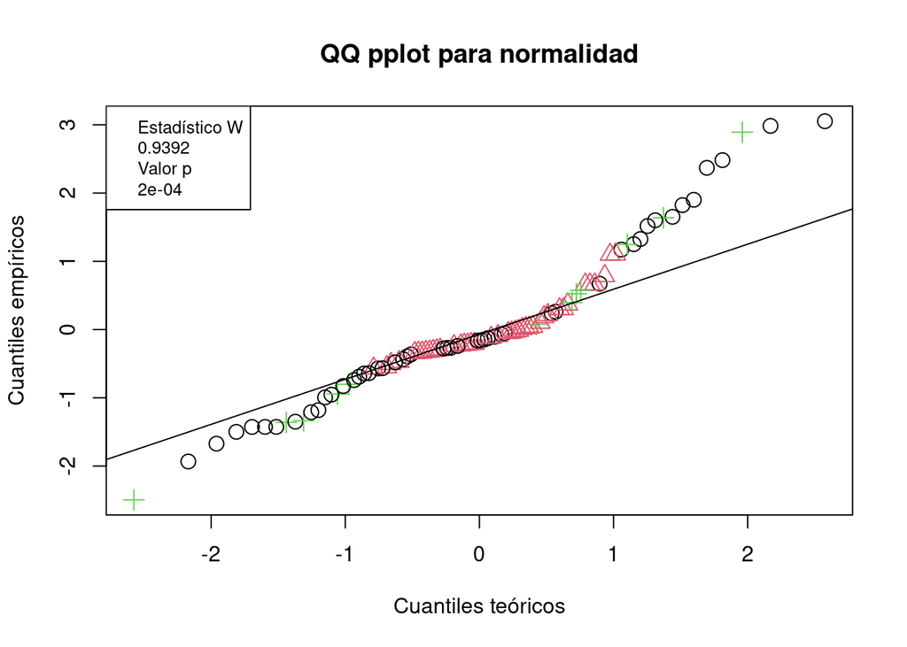

Y como se puede observar, existe una amplia concentración de valores alrededor de los cuantiles teórcios cuando se está cerca a la media, es decir, a cero, pero este no es el caso en las colas, ya que los cuantiles empíricos se alejan de los teóricos, sobre todo con la cola superior, y esto sucede fundamentalmente con los vehículos tipo `Otro` y con algunos tipo `sedan`, por lo que es razonable pensar que los vehículos `hatchback`, cuyo modelo ajustado está dado por la ecuación $\hat{3}$ sí cumplen con el supuesto de normalidad, mientras que los demás presentan dificultades al tener distribuciones con colas más pesadas. Además, se realizó un test de Shapiro-Wilk para comprar la normalidad para las cien observaciones, con las siguientes hipótesis:

- $H_0:$ Los residuales tienen una distribución normal.
- $H_1:$ Los residuales *no* tienen una distribución normal.

Y sus resultados se pueden ver en el margen superior izquierdo de la gráfica, donde se ve que el valor p es $V_p = 2 \times 10 ^{-4}$, lo cual es menor que cualquier $\alpha$, y en particular, que un $\alpha = 0.05 > V_p$, de manera que se rechaza la hipótesis nula y se concluye que no hay evidencia muestral suficiente para sugerir que los errores tienen una distribución normal.

`PREGUNTA. ¿Concluyo sobre errores o residuales? ¿Y es correcto decir que uno de los modelos cumple y los otros no?`